# Illustrate Some Correlation Limitations and Fallacies in R

Author

Rick Dean

Abstract

The following are notes and R scripts inspired by the article [Illustrate Some Correlation Limitations and Fallacies in R](http://svmiller.com/blog/2020/01/illustrate-correlation-fallacies-limitations-in-r/) by Steve Miller.

```r
library(data.table)
library(magrittr)
library(ggplot2)
library(purrr)
library(here)
library(ggrepel)
library(RplotterPkg)
library(RregressPkg)
```

# 1 Some Correlation Limitations and Fallacies in R

## 1.1 Anscombe’s Quartet

> Here, Anscombe created four data sets, each with 11 observations and two variables (x and y). All four quartets have the same mean for x and y, the same variance for x and y, the same regression line (y-intercept and slope for x), the same residual sum of squares, and the same correlation. However, they look quite differently.

Anscombe’s data and x/y stats

Base R datasets has the anscombe data.

```r
data("anscombe")
anscombe_dt <- data.table::data.table(anscombe)
anscombe_stats_dt <- data.table(
  var = colnames(anscombe_dt)
) %>%
  .[, `:=`(
  mean = lapply(anscombe_dt, function(x) format(mean(x),digits = 4,nsmall=4)),
  sd = lapply(anscombe_dt, function(x) format(sd(x),digits = 4,nsmall=4)))]
```

```r
RplotterPkg::create_table(
  x = anscombe_stats_dt,
  container_width_px = 300
)
```

The x/y variable mean and sd for each of the 4 Anscombe Quartets

| var | mean | sd |
| --- | --- | --- |
| x1 | 9.0000 | 3.3166 |
| x2 | 9.0000 | 3.3166 |
| x3 | 9.0000 | 3.3166 |
| x4 | 9.0000 | 3.3166 |
| y1 | 7.5009 | 2.0316 |
| y2 | 7.5009 | 2.0317 |
| y3 | 7.5000 | 2.0304 |
| y4 | 7.5009 | 2.0306 |

Anscombe’s plots

Reshape *anscombe_dt* in the “long” format to give us a data.table with three columns (*Quartet*, *X*, *Y*).

```r
anscombe_long_dt <- data.table::melt(anscombe_dt, measure = patterns("^x","^y"),value.name = c("X","Y")) %>%
  .[, .(Quartet = paste0("Quartet ", variable), X = X, Y = Y)]
```

Define a function for building an individual Quartet plot.

```r
build_quartet_plot <- function(id, dt, names){
  # define the Quartet data to plot
  quartet_dt <- dt[Quartet == names[[id]],]

  # define OLS x/y
  X_mt <- as.matrix(cbind(1,quartet_dt$X))
  colnames(X_mt) <- c("X1", "X2")
  Y_mt <- as.matrix(quartet_dt$Y)

  # calculate the OLS
  quartet_ols <- RregressPkg::ols_calc(  # define the Quartet OLS line fit
    X_mt = X_mt,
    Y_mt = Y_mt
  )

  # calculate the confidence intervals
  reg <- lm(Y ~ X, data = quartet_dt)
  ci <- stats::predict(reg, interval = "confidence")

  # modify quartet_dt with fitted and ci values
  quartet_dt[, `:=`(fitted_vals = quartet_ols$fitted_vals,lwr = ci[,2], upr = ci[,3])]

  hide_x_tics <- TRUE
  if(id == 3 | id == 4){
    hide_x_tics <- FALSE
  }
  hide_y_tics <- TRUE
  if(id == 1 | id == 3){
    hide_y_tics <- FALSE
  }

  # create the ggplot2 scatter plot
  aplot <- RplotterPkg::create_scatter_plot(
    df = quartet_dt,
    aes_x = "X",
    aes_y = "Y",
    subtitle = names[[id]],
    hide_x_tics = hide_x_tics,
    hide_y_tics = hide_y_tics,
    x_limits = c(0,20),
    x_major_breaks = seq(0,20,5),
    y_limits = c(0,20),
    y_major_breaks = seq(0,20,5),
    x_minor_breaks = NULL,
    y_minor_breaks = NULL,
    CI_show_line = TRUE,
    aes_CI_lwr = "lwr",
    aes_CI_upr = "upr",
    CI_show_ribbon = TRUE,
    CI_line_width = 0.5,
    CI_line_color = "red"
  ) + ggplot2::geom_path(aes(X, fitted_vals), color = "blue")
  return(aplot)
}
```

Plot the 4 Quartets.

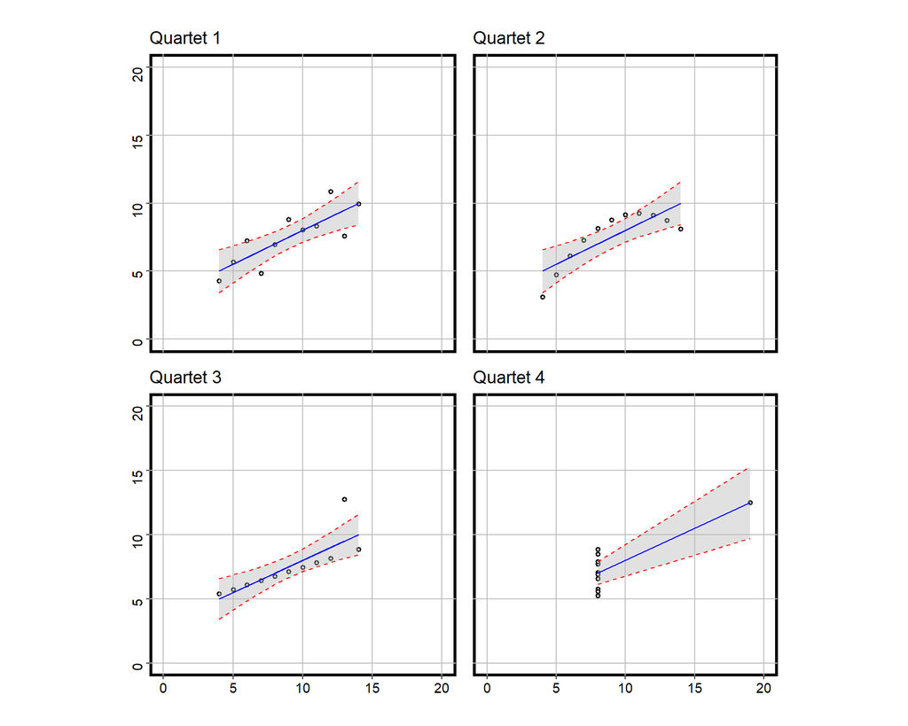

The 4 Anscombe quartets

```r
# create the 4 quartet ggplot2 scatter plots:
quartet_names <- c("Quartet 1","Quartet 2","Quartet 3","Quartet 4")
plot_lst <- purrr::map(
  1:4,
  build_quartet_plot,
  dt = anscombe_long_dt,
  names = quartet_names
)
# define the multipanel layout of 2 columns and 2 rows:
layout <- list(
  plots = plot_lst,
  rows = c(1, 1, 2, 2),
  cols = c(1, 2, 1, 2)
)
# plot the 4 quartets
RplotterPkg::multi_panel_grid(
  layout = layout,
  col_widths = c(9.5, 9), # in cm
  row_heights = c(9.5, 9.5) # in cm
)
```

## 1.2 Simpson’s Paradox

Mr. Miller describes Simpson’s Paradox as…

> Simpson’s paradox is a well-known problem of correlation in which a correlation analysis, almost always done in a bivariate context, may reveal a relationship that is reversed upon the introduction of some third variable.

Wikipedia describes Simpson’s Paradox as… > …a phenomenon in probability and statistics, in which a trend appears in several different groups of data but disappears or reverses when these groups are combined.

State expenditures versus average SAT score

We illustrate Simpson’s Paradox with data from the paper [Getting What You Pay For](https://www.uvm.edu/~dguber/research/JSE99.pdf) by Deborah Lynn Guber, The University of Vermont.

Set up the data set.

```r
data_path <- file.path(here::here(), "Miller", "data", "Guber99.rda")
load(file = data_path)
guber_dt <- data.table::as.data.table(Guber99) %>%
  .[, .(State = state, Expenditure = expendpp, AvgSAT = total, PercTakers = perctakers)]
```

Define the OLS fits and confidence intervals.

```r
sd_x <- sd(guber_dt$Expenditure)
mean_x <- mean(guber_dt$Expenditure)
sd_y <- sd(guber_dt$AvgSAT)
mean_y <- mean(guber_dt$AvgSAT)
guber_scaled_df <- data.frame(
  x = (guber_dt$Expenditure - mean_x)/sd_x,
  y = (guber_dt$AvgSAT - mean_y)/sd_y
)

guber_ols <- RregressPkg::ols_calc(df = guber_dt, formula_obj = AvgSAT ~ Expenditure)
guber_scaled_ols <- RregressPkg::ols_calc(df = guber_scaled_df, formula_obj = x ~ y)

formula_obj = lm(AvgSAT ~ Expenditure , data = guber_dt)
ci <- stats::predict(formula_obj, interval = "confidence")
guber_dt[, `:=`(fitted_vals = ci[,1], lwr = ci[,2], upr = ci[,3])]
```

Plot the points, fitted line, and the confidence intervals.

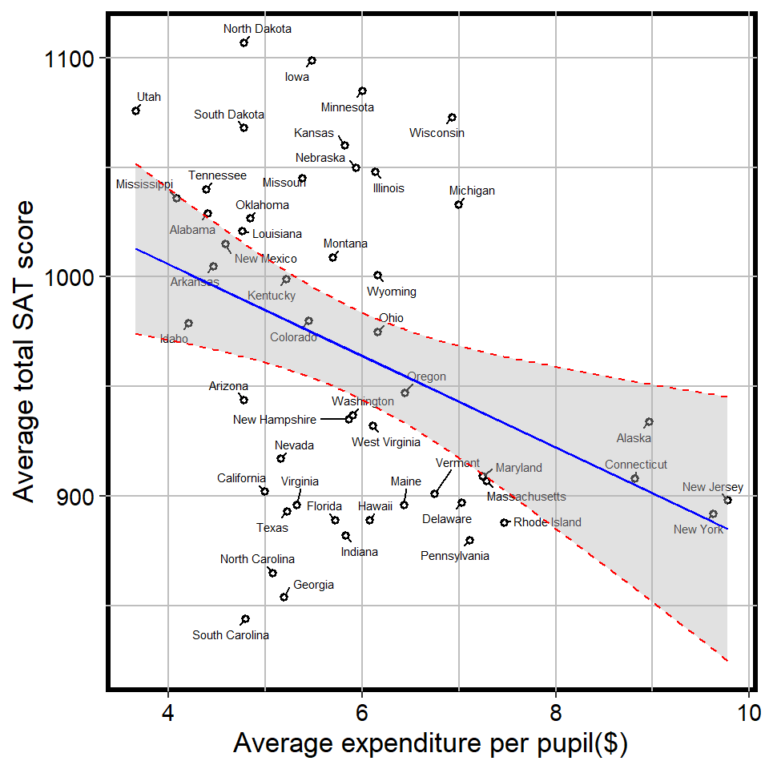

Regression model - AvgSAT ~ Expenditure

```r
RplotterPkg::create_scatter_plot(
  df = guber_dt,
  aes_x = "Expenditure",
  aes_y = "AvgSAT",
  aes_label = "State",
  aes_label_size = 2,
  x_title = "Average expenditure per pupil($)",
  y_title = "Average total SAT score",
  rot_y_tic_label = T,
  CI_show_line = TRUE,
  aes_CI_lwr = "lwr",
  aes_CI_upr = "upr",
  CI_show_ribbon = TRUE,
  CI_line_width = 0.5,
  CI_line_color = "red"
) + ggplot2::geom_path(aes(Expenditure, fitted_vals), color = "blue")
```

Take Away: There appears to be a negetive relationship between `Expenditure` and `AvgSat`

Does the relation hold up across levels of state percent SAT takers

Break out percent SAT takers into four levels.

```r
breaks_v <- stats::quantile(guber_dt$PercTakers, probs = seq(0.25, 1.0, 0.25))
guber_dt[, SAT_take :=
  fcase(
    PercTakers <= breaks_v[[1]], "Lowest Quartile",
    PercTakers > breaks_v[[1]] & PercTakers <= breaks_v[[2]], "Second Quartile",
    PercTakers > breaks_v[[2]] & PercTakers <= breaks_v[[3]], "Third Quartile",
    PercTakers > breaks_v[[3]] & PercTakers <= breaks_v[[4]], "Highest Quartile"
  )
] %>%
  .[, SAT_take := ordered(SAT_take, levels = c("Lowest Quartile","Second Quartile","Third Quartile","Highest Quartile"))]
```

```r
RplotterPkg::create_table(
  x = guber_dt[1:6,],
  container_width_px = 600
)
```

Percent SAT takers among states catagorized into 4 quartile groups.

| State | Expenditure | AvgSAT | PercTakers | fitted_vals | lwr | upr | SAT_take |
| --- | --- | --- | --- | --- | --- | --- | --- |
| Alabama | 4.405 | 1029 | 8 | 997.2637 | 967.5351 | 1026.9923 | Lowest Quartile |
| Alaska | 8.963 | 934 | 47 | 902.0372 | 852.7930 | 951.2814 | Third Quartile |
| Arizona | 4.778 | 944 | 27 | 989.4709 | 963.5669 | 1015.3749 | Second Quartile |
| Arkansas | 4.459 | 1005 | 6 | 996.1355 | 966.9936 | 1025.2774 | Lowest Quartile |
| California | 4.992 | 902 | 45 | 985.0000 | 960.9955 | 1009.0045 | Third Quartile |
| Colorado | 5.443 | 980 | 29 | 975.5776 | 954.5649 | 996.5904 | Third Quartile |

Compute and show the correlation between *Expenditure* and *AvgSAT* across levels of *SAT_take*.

```r
guber_dt[, Pearson_r := round(cor(.SD$Expenditure, .SD$AvgSAT),3),by = SAT_take]
```

```r
cor_by_quartile_dt <- guber_dt[, .SD[1L], by = SAT_take] %>%
  .[order(SAT_take), .(SAT_take, Pearson_r)]

RplotterPkg::create_table(
  x = cor_by_quartile_dt,
  container_width_px = 300
)
```

SAT Test-Taker Percentage Quartile

| SAT_take | Pearson_r |
| --- | --- |
| Lowest Quartile | 0.317 |
| Second Quartile | 0.099 |
| Third Quartile | 0.395 |
| Highest Quartile | 0.140 |

Take Away: Overall correlation between `Expenditure` and `AvgSAT` is negative. Across the quartile groups all the correlations are positive.

Plot `Expenditure` versus `AvgSAT` across the 4 quartile groups

Define a function for building an individual quartile plot.

```r
build_quartile_plot <- function(id, dt, quartile_names){
  # define the quartile data to plot
  quartile_dt <- dt[SAT_take == quartile_names[[id]],]

  # define OLS x/y
  X_mt <- as.matrix(cbind(1,quartile_dt$Expenditure))
  colnames(X_mt) <- c("X1", "X2")
  Y_mt <- as.matrix(quartile_dt$AvgSAT)

  # calculate the OLS
  quartile_ols <- RregressPkg::ols_calc(
    X_mt = X_mt,
    Y_mt = Y_mt
  )

  # calculate the confidence intervals
  ols_lm <- lm(AvgSAT ~ Expenditure, data = quartile_dt)
  ci <- stats::predict(ols_lm, interval = "confidence")

  # modify quartile_dt with fitted and ci values
  quartile_dt[, `:=`(fitted_vals = quartile_ols$fitted_vals,lwr = ci[,2], upr = ci[,3])]

  hide_x_tics <- TRUE
  if(id == 3 | id == 4){
    hide_x_tics <- FALSE
  }
  hide_y_tics <- TRUE
  if(id == 1 | id == 3){
    hide_y_tics <- FALSE
  }

  # create the ggplot2 scatter plot
  aplot <- RplotterPkg::create_scatter_plot(
    df = quartile_dt,
    aes_x = "Expenditure",
    aes_y = "AvgSAT",
    caption = quartile_names[[id]],
    hide_x_tics = hide_x_tics,
    hide_y_tics = hide_y_tics,
    x_limits = c(2,10),
    x_major_breaks = seq(2,10,2),
    y_limits = c(800,1200),
    y_major_breaks = seq(800,1200,100),
    rot_y_tic_label = T,
    x_minor_breaks = NULL,
    y_minor_breaks = NULL,
    CI_show_line = TRUE,
    aes_CI_lwr = "lwr",
    aes_CI_upr = "upr",
    CI_show_ribbon = TRUE,
    CI_line_width = 0.5,
    CI_line_color = "red"
  ) + ggplot2::geom_path(aes(Expenditure, fitted_vals), color = "blue")

  return(aplot)
}
```

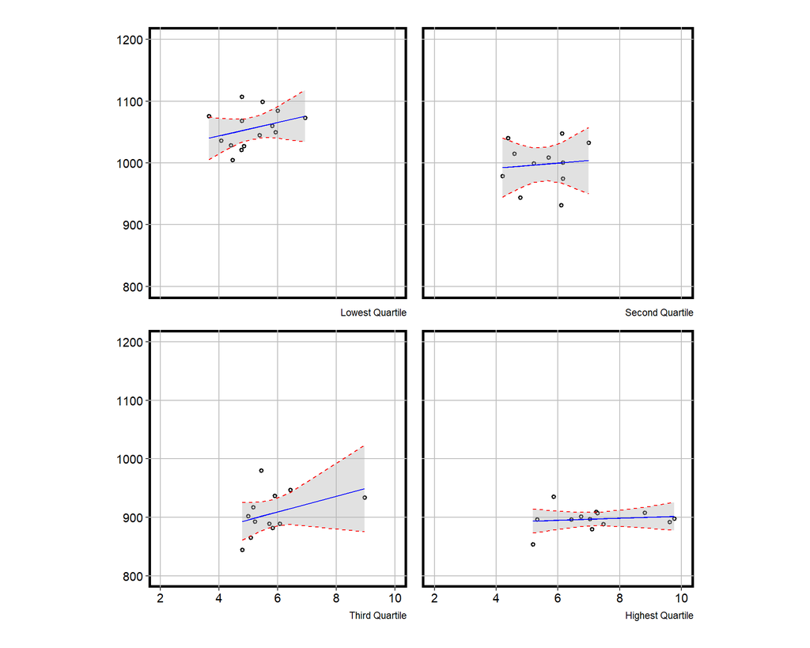

Expenditure versus AvgSAT across the 4 quartile groups

```r
plot_lst <- purrr::map(
  1:4,
  build_quartile_plot,
  dt = guber_dt,
  quartile_names = c("Lowest Quartile","Second Quartile","Third Quartile","Highest Quartile")
)

# define the multipanel layout of 2 columns and 2 rows:
layout <- list(
  plots = plot_lst,
  rows = c(1, 1, 2, 2),
  cols = c(1, 2, 1, 2)
)
# plot the 4 quartile groups
RplotterPkg::multi_panel_grid(
  layout = layout,
  col_widths = c(9.5, 9), # in cm
  row_heights = c(9.5, 9.5) # in cm
)
```

## 1.3 Ecological Fallacy

Mr. Miller describes the ecological fallacy as …

> …inferences and correlations at the individual-level need not be equivalent at the group level.

Illiteracy rates from the 1930 Census

Set up the data set.

```r
data_path <- file.path(here::here(), "Miller", "data", "illiteracy30.rda")
load(file = data_path)
illit_dt <- data.table::as.data.table(illiteracy30)
illit_dt <- illit_dt[, !c("state")]
```

Get the sums for each category.

```r
illit_sums_dt <- illit_dt[,lapply(illit_dt,sum)]
```

Reshape *illit_sums_dt* into a “long” form.

```r
illit_long_dt <- data.table::melt(illit_sums_dt, measure.vars = names(illit_sums_dt), variable.name = "Race", value.name = "Number")
```

Add a *category* and *literacy* columns.

```r
illit_long_dt[, `:=`(category = c("Total Population", "Total Population",
                      "Native White", "Native White",
                      "White, Foreign/Mixed Parentage","White, Foreign/Mixed Parentage",
                      "Foreign-Born White", "Foreign-Born White",
                      "Black", "Black"),
                     literacy = rep(c("Total","Illiterate"),5))
              ]
```

Add *prop* for proportions.

```r
illit_long_dt[, prop := round(.SD$Number/max(.SD$Number),3), by = category]
```

```r
RplotterPkg::create_table(
  x = illit_long_dt[literacy != "Total", .(category, prop)],
  container_width_px = 300
)
```

Illiteracy Rates in the 1930 U.S. Census

| category | prop |
| --- | --- |
| Total Population | 0.043 |
| Native White | 0.018 |
| White, Foreign/Mixed Parentage | 0.006 |
| Foreign-Born White | 0.099 |
| Black | 0.163 |

Take Away: The `Foreign-Born White` group is showing nearly a 10% rate in illiteracy.

Compare rates of illiteracy both in state foreign born and overall state

Reread data.

```r
data_path <- file.path(here::here(), "Miller", "data", "illiteracy30.rda")
load(file = data_path)
illit_dt <- data.table::as.data.table(illiteracy30)
```

Create new columns for *illit_dt*.

```r
illit_dt[, `:=`(FB_prop = fbwhite/pop, Ill_All_prop = pop_il/pop, Ill_FB_prop = fbwhite_il/fbwhite)]
```

Reshape `illit_dt` to “long” form for variables *Ill_All_prop* and *Ill_FB_prop*.

```r
illit_long_dt <- data.table::melt(illit_dt, measure.vars = c("Ill_All_prop", "Ill_FB_prop"), variable.name = "Ill_All_or_FB", value.name = "Ill_ALL_or_FB_prop") %>%
  .[, .(FB_prop, Ill_All_or_FB, Ill_ALL_or_FB_prop)]
```

Compute the correlation between *FB_prop* and *Ill_ALL_or_FB_prop* across *Ill_All_or_FB*.

```r
illit_long_dt[, Pearson_r := round(cor(.SD$FB_prop, .SD$Ill_ALL_or_FB_prop),3),by=Ill_All_or_FB]
```

Relabel *Ill_All_or_FB* values.

```r
# overall_label <-  paste0("Overall State Illiterate R2 = ",illit_long_dt$Pearson_r[[1]])
# fb_label <- paste0("Foeign-Born State Illiterate R2 = ",illit_long_dt$Pearson_r[[50]])
#
# illit_long_dt[, Ill_All_or_FB := fifelse(Ill_All_or_FB == "Ill_All_prop",overall_label, fb_label)] %>%
# .[, Ill_All_or_FB := as.factor(Ill_All_or_FB)]
```

Define a function that computes the OLS estimates for formula *Ill_ALL_or_FB_prop* ~ *FB_prop* and plots the fitted values and confidence intervals.

```r
build_group_plot <- function(id, dt, group_names, captions){
  # define the group data to plot
  group_dt <- dt[Ill_All_or_FB == group_names[[id]], ]

  # define OLS x/y
  X_mt <- as.matrix(cbind(1, group_dt$FB_prop))
  colnames(X_mt) <- c("X1", "X2")
  Y_mt <- as.matrix(group_dt$Ill_ALL_or_FB_prop)

  # calculate the OLS
  group_ols <- RregressPkg::ols_calc(
    X_mt = X_mt,
    Y_mt = Y_mt
  )

  # calculate the confidence intervals
  ols_lm <- lm(Ill_ALL_or_FB_prop ~ FB_prop, data = group_dt)
  ci <- stats::predict(ols_lm, interval = "confidence")

  # modify group_dt with fitted and ci values
  group_dt[, `:=`(fitted_vals = group_ols$fitted_vals,lwr = ci[,2], upr = ci[,3])]

  # create the ggplot2 scatter plot
  hide_y_tics <- TRUE
  y_title = NULL
  if(id == 1){
    hide_y_tics <- FALSE
    y_title <- "Percent Illiterate"
  }
  aplot <- RplotterPkg::create_scatter_plot(
    df = group_dt,
    aes_x = "FB_prop",
    aes_y = "Ill_ALL_or_FB_prop",
    x_labels = scales::percent,
    y_labels = scales::percent,
    x_title = "Percent Foreign Born",
    y_title = y_title,
    rot_y_tic_label = T,
    hide_y_tics = hide_y_tics,
    caption = captions[[id]],
    CI_show_line = TRUE,
    aes_CI_lwr = "lwr",
    aes_CI_upr = "upr",
    CI_show_ribbon = TRUE,
    CI_line_width = 0.5,
    CI_line_color = "red"
  ) + ggplot2::geom_path(aes(FB_prop, fitted_vals), color = "blue")
  return(aplot)
}
```

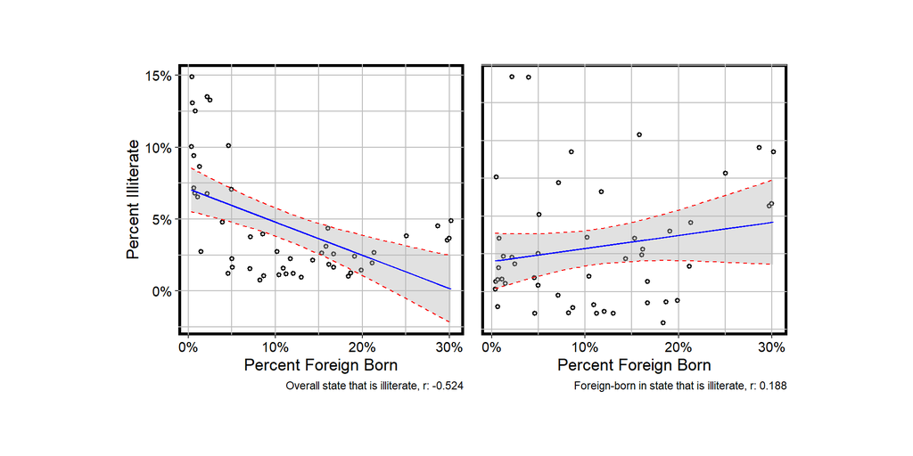

Rates of illiteracy both in state foreign born and overall state

```r
plot_lst <- purrr::map(
  1:2,
  build_group_plot,
  dt = illit_long_dt,
  group_names = c("Ill_All_prop", "Ill_FB_prop"),
  captions = c("Overall state that is illiterate, r: -0.524",
               "Foreign-born in state that is illiterate, r: 0.188")
)

# define the multipanel layout of 2 columns and 1 row:
layout <- list(
  plots = plot_lst,
  rows = c(1, 1),
  cols = c(1, 2)
)

# plot the 2 groups
RplotterPkg::multi_panel_grid(
  layout = layout,
  col_widths = c(9.8, 9),
  row_heights = 9.5
)
```